# IMT 573 - Final Examination

Points: 100

Name: Andy Nguyen

### Instructions

This is a take-home final examination. You may use your computer, books/articles, notes, course materials, etc., but all work must be your own! Please review the course policy on AI-based learning tools. References must be appropriately cited. Please justify your answers and show all work; a complete argument must be presented to obtain full credit. Before beginning this exam, please ensure you have access to data programming environments used in the course; this can be on your own personal computer or on shared infrastructure hosted by the university.

1. Download the exam template notebook file from Canvas. Open exam notebook and supply your solutions to the exam by editing the notebook.
2. Be sure the exam contains your full name.
3. Be sure to include well-documented (e.g. commented) code chucks, figures, and clearly written text chunk explanations as necessary. Any figures should be clearly labeled and appropriately referenced within the text. Be sure that each visualization adds value to your written explanation; avoid redundancy -- you do not need four different visualizations of the same pattern.
4. **Collaboration is not allowed on this exam. You may only speak with the course instructor about this material.**
5. All materials and resources that you use (with the exception of lecture slides) must be appropriately referenced within your assignment.
6. Remember partial credit will be awarded for each question for which a serious attempt at finding an answer has been shown. Students are **strongly** encouraged to attempt each question and to document their reasoning process even if they cannot find the correct answer. If you would like to include code to show this process, but it does not run without errors, you can do so by commenting out that code.
7. When you have completed the assignment and have **checked** that your code both runs in the Console and compiles correctly rename the file to `YourLastName_YourFirstName.ipynb`, and submit BOTH your HTML and notebook files on Canvas.

### Statement of Compliance

You **must** include the a "signed" Statement of Compliance in your submission. The Compliance Statement is found below. You must include this text, word-for-word, in your final exam submission. Adding your name indicates you have read the statement and agree to its terms. Failure to do so will result in your exam **not** being accepted.

**Statement of Compliance**

I affirm that I have had no conversation regarding this exam with any persons other than the instructor. Further, I certify that the attached work represents my own thinking. Any information, concepts, or words that originate from other sources are cited in accordance with University of Washington guidelines as published in the Academic Code (available on the course website). I am aware of the serious consequences that result from improper discussions with others or from the improper citation of work that is not my own.

Andy Nguyen

11/30/25

For this assignment, you'll need (at least) the following packages. If the package does not load, be sure it is properly installed.

```python
import pandas as pd
import numpy as np
import matplotlib.pyplot as plt
import seaborn as sns
import statsmodels.api as sm
```

### Problem 1

Points: 20

In this problem we will use data on infidelity, known as the Fair's Affairs dataset. The `Affairs` dataset is available as part of the `datasets` package in`statsmodels`. This data comes from a survey conducted by Psychology Today in 1969, see Greene (2003) and Fair (1978) for more information.

The dataset contains various self-reported characteristics of 6366 participants, including how often the respondent engaged in extramarital sexual intercourse during the past year, as well as their gender, age, year married, whether they had children, their religiousness (on a 5-point scale, from 1=anti to 5=very), education, occupation (Hillingshead 7-point classification with reverse numbering), and a numeric self-rating of their marriage (from 1=very unhappy to 5=very happy).

(a) Describe the participants. Use descriptive, summarization, and exploratory techniques to describe the participants in the study. Tell us the average/mean of children count ? What is the average age of respondents? In your response comment on any ethical and privacy concerns you have with this dataset.

```python
affairs = sm.datasets.fair.load_pandas().data
print(sm.datasets.fair.NOTE)
```

```
::

    Number of observations: 6366
    Number of variables: 9
    Variable name definitions:

        rate_marriage   : How rate marriage, 1 = very poor, 2 = poor, 3 = fair,
                        4 = good, 5 = very good
        age             : Age
        yrs_married     : No. years married. Interval approximations. See
                        original paper for detailed explanation.
        children        : No. children
        religious       : How relgious, 1 = not, 2 = mildly, 3 = fairly,
                        4 = strongly
        educ            : Level of education, 9 = grade school, 12 = high
                        school, 14 = some college, 16 = college graduate,
                        17 = some graduate school, 20 = advanced degree
        occupation      : 1 = student, 2 = farming, agriculture; semi-skilled,
                        or unskilled worker; 3 = white-colloar; 4 = teacher
                        counselor social worker, nurse; artist, writers;
                        technician, skilled worker, 5 = managerial,
                        administrative, business, 6 = professional with
                        advanced degree
        occupation_husb : Husband's occupation. Same as occupation.
        affairs         : measure of time spent in extramarital affairs

    See the original paper for more details.
```

```python
affairs.head()
```

|  | rate_marriage | age | yrs_married | children | religious | educ | occupation | occupation_husb | affairs |
| --- | --- | --- | --- | --- | --- | --- | --- | --- | --- |
| 0 | 3.0 | 32.0 | 9.0 | 3.0 | 3.0 | 17.0 | 2.0 | 5.0 | 0.111111 |
| 1 | 3.0 | 27.0 | 13.0 | 3.0 | 1.0 | 14.0 | 3.0 | 4.0 | 3.230769 |
| 2 | 4.0 | 22.0 | 2.5 | 0.0 | 1.0 | 16.0 | 3.0 | 5.0 | 1.400000 |
| 3 | 4.0 | 37.0 | 16.5 | 4.0 | 3.0 | 16.0 | 5.0 | 5.0 | 0.727273 |
| 4 | 5.0 | 27.0 | 9.0 | 1.0 | 1.0 | 14.0 | 3.0 | 4.0 | 4.666666 |

```python
#Summary statistics for all numeric variables
affairs.describe()
```

|  | rate_marriage | age | yrs_married | children | religious | educ | occupation | occupation_husb | affairs |
| --- | --- | --- | --- | --- | --- | --- | --- | --- | --- |
| count | 6366.000000 | 6366.000000 | 6366.000000 | 6366.000000 | 6366.000000 | 6366.000000 | 6366.000000 | 6366.000000 | 6366.000000 |
| mean | 4.109645 | 29.082862 | 9.009425 | 1.396874 | 2.426170 | 14.209865 | 3.424128 | 3.850141 | 0.705374 |
| std | 0.961430 | 6.847882 | 7.280120 | 1.433471 | 0.878369 | 2.178003 | 0.942399 | 1.346435 | 2.203374 |
| min | 1.000000 | 17.500000 | 0.500000 | 0.000000 | 1.000000 | 9.000000 | 1.000000 | 1.000000 | 0.000000 |
| 25% | 4.000000 | 22.000000 | 2.500000 | 0.000000 | 2.000000 | 12.000000 | 3.000000 | 3.000000 | 0.000000 |
| 50% | 4.000000 | 27.000000 | 6.000000 | 1.000000 | 2.000000 | 14.000000 | 3.000000 | 4.000000 | 0.000000 |
| 75% | 5.000000 | 32.000000 | 16.500000 | 2.000000 | 3.000000 | 16.000000 | 4.000000 | 5.000000 | 0.484848 |
| max | 5.000000 | 42.000000 | 23.000000 | 5.500000 | 4.000000 | 20.000000 | 6.000000 | 6.000000 | 57.599991 |

```python
#Mean children count
mean_children = affairs['children'].mean()
mean_children
```

```
1.3968740182218033
```

```python
#Mean age of respondents
mean_age = affairs['age'].mean()
mean_age
```

```
29.082862079798932
```

Because this dataset contains sensitive personal information—such as marital satisfaction, religiosity, and extramarital sexual behavior—there are important ethical and privacy considerations. Although the dataset is anonymized, combinations of variables (age, years married, number of children, occupation) could still potentially identify real individuals, especially in smaller communities. Additionally, it is not clear whether the original participants consented for their responses to be publicly shared for research and teaching, which raises concerns about privacy and data governance. Any analysis should therefore be handled carefully, avoiding stigmatizing interpretations and respecting the sensitive nature of the topics measured.

(b) Suppose we want to explore the characteristics of participants who engage in extramarital sexual intercourse (i.e. affairs). Instead of modeling the number of affairs, consider the binary outcome - had an affair versus didn't have an affair. Create a new variable to capture this response variable of interest. What might the advantages and disadvantages of this approach to modeling the data be in this context?

```python
#Create a binary outcome variable: 1 = had an affair, 0 = no affair
#We classify anyone with 'affairs' > 0 as having had an affair
affairs['had_affair'] = (affairs['affairs'] > 0).astype(int)
```

To explore who engaged in extramarital affairs, I first created a binary variable that indicates whether a respondent had any affair activity using the 'affairs' variable. This new variable equals 1 if the respondent reported any amount of affair involvement and 0 otherwise.

Modeling the data using this binary outcome has several advantages. It simplifies interpretation, allowing us to focus on the broader question of whether an affair occurred rather than the exact amount of time spent having affairs, which may be difficult to measure reliably. A binary outcome is also easier to model with logistic regression and tends to be more robust to extreme values, such as unusually high affair scores that could skew results.

However, this approach also has important limitations. By converting a continuous measure into a binary one, we lose information about the intensity or frequency of affairs. Someone who had one brief encounter is treated the same as someone with extensive affair activity, which may mask meaningful differences in behavior. Additionally, the threshold of “greater than zero” assumes that any reported affair, no matter how small, is equally significant, which may not reflect the real-world variation captured in the original data.

(c) Use an appropriate regression model to explore the relationship between having an affair (binary) and other personal characteristics. Comment on which covariates seem to be predictive of having an affair and which do not.

```python
#Import logistic regression tools from statsmodels
import statsmodels.formula.api as smf

#Fit a logistic regression model
#Logistic regression is appropriate when the outcome is binary.
#The model estimates how each predictor changes the log-odds of having an affair.
model = smf.logit(
    formula='''
        had_affair ~ age
        + yrs_married
        + children
        + religious
        + educ
        + occupation
        + occupation_husb
        + rate_marriage
    ''',
    data=affairs
).fit()

#Print the full model summary table
print(model.summary())
```

```
Optimization terminated successfully.
         Current function value: 0.545314
         Iterations 6
                           Logit Regression Results
==============================================================================
Dep. Variable:             had_affair   No. Observations:                 6366
Model:                          Logit   Df Residuals:                     6357
Method:                           MLE   Df Model:                            8
Date:                Mon, 01 Dec 2025   Pseudo R-squ.:                  0.1327
Time:                        06:52:58   Log-Likelihood:                -3471.5
converged:                       True   LL-Null:                       -4002.5
Covariance Type:            nonrobust   LLR p-value:                5.807e-224
===================================================================================
                      coef    std err          z      P>|z|      [0.025      0.975]
-----------------------------------------------------------------------------------
Intercept           3.7257      0.299     12.470      0.000       3.140       4.311
age                -0.0605      0.010     -5.885      0.000      -0.081      -0.040
yrs_married         0.1100      0.011     10.054      0.000       0.089       0.131
children           -0.0042      0.032     -0.134      0.893      -0.066       0.058
religious          -0.3752      0.035    -10.792      0.000      -0.443      -0.307
educ               -0.0392      0.015     -2.533      0.011      -0.070      -0.009
occupation          0.1602      0.034      4.717      0.000       0.094       0.227
occupation_husb     0.0124      0.023      0.541      0.589      -0.033       0.057
rate_marriage      -0.7161      0.031    -22.784      0.000      -0.778      -0.655
===================================================================================
```

(d) Use a model selection procedure to obtain a "best" fit model. Is the model different from the full model you fit in part (c)? Which variables are included in the "best" fit model? [Hint: stepwise selection]

```python
#List of all possible predictors
predictors = ["age", "yrs_married", "children", "religious",
              "educ", "occupation", "occupation_husb", "rate_marriage"]

#Start with an empty model
selected = []

#Stepwise selection using AIC
def compute_aic(vars_list):
    formula = "had_affair ~ " + " + ".join(vars_list)
    model = smf.logit(formula=formula, data=affairs).fit(disp=False)
    return model.aic, model

best_aic = float("inf")
best_model = None

for var in predictors:
    trial_vars = selected + [var]
    aic, model = compute_aic(trial_vars)
    if aic < best_aic:
        best_aic = aic
        best_model = model
        selected.append(var)

print("Selected variables:", selected)
print(best_model.summary())
```

```
Selected variables: ['age', 'yrs_married', 'religious', 'educ', 'occupation', 'rate_marriage']
                           Logit Regression Results
==============================================================================
Dep. Variable:             had_affair   No. Observations:                 6366
Model:                          Logit   Df Residuals:                     6359
Method:                           MLE   Df Model:                            6
Date:                Mon, 01 Dec 2025   Pseudo R-squ.:                  0.1326
Time:                        06:52:58   Log-Likelihood:                -3471.6
converged:                       True   LL-Null:                       -4002.5
Covariance Type:            nonrobust   LLR p-value:                3.821e-226
=================================================================================
                    coef    std err          z      P>|z|      [0.025      0.975]
---------------------------------------------------------------------------------
Intercept         3.7371      0.296     12.622      0.000       3.157       4.317
age              -0.0602      0.010     -5.867      0.000      -0.080      -0.040
yrs_married       0.1095      0.010     11.237      0.000       0.090       0.129
religious        -0.3760      0.035    -10.856      0.000      -0.444      -0.308
educ             -0.0380      0.015     -2.482      0.013      -0.068      -0.008
occupation        0.1628      0.034      4.838      0.000       0.097       0.229
rate_marriage    -0.7153      0.031    -22.804      0.000      -0.777      -0.654
=================================================================================
```

(e) Interpret the model parameters using the model from part (d).

(f) Create an artificial test dataset where martial rating varies from 1 to 5 randomly and all other variables are set to their means. Use this artificial dataset as your test dataset to obtain predicted probabilities of having an affair for case in the test data. Interpret your results and use a visualization to support your interpretation.

```python
#Set random seed for reproducibility
np.random.seed(42)

#Create a test dataset of 100 cases with marital ratings from 1–5 randomly
test_data = pd.DataFrame({
    'rate_marriage': np.random.randint(1, 6, 100),
    'age': affairs['age'].mean(),
    'yrs_married': affairs['yrs_married'].mean(),
    'religious': affairs['religious'].mean(),
    'educ': affairs['educ'].mean(),
    'occupation': affairs['occupation'].mean()
})

#Predict probabilities using the model from part (d)
test_data['pred_prob'] = best_model.predict(test_data)
test_data.head()
```

|  | rate_marriage | age | yrs_married | religious | educ | occupation | pred_prob |
| --- | --- | --- | --- | --- | --- | --- | --- |
| 0 | 4 | 29.082862 | 9.009425 | 2.42617 | 14.209865 | 3.424128 | 0.313517 |
| 1 | 5 | 29.082862 | 9.009425 | 2.42617 | 14.209865 | 3.424128 | 0.182573 |
| 2 | 3 | 29.082862 | 9.009425 | 2.42617 | 14.209865 | 3.424128 | 0.482895 |
| 3 | 5 | 29.082862 | 9.009425 | 2.42617 | 14.209865 | 3.424128 | 0.182573 |
| 4 | 5 | 29.082862 | 9.009425 | 2.42617 | 14.209865 | 3.424128 | 0.182573 |

(g) Reflect on your analysis in this problem. After completing all the parts of this analysis what remaining and additional ethical and privacy conerns do you have?

Even after completing the analysis, several ethical and privacy concerns remain. The dataset contains very sensitive information about marriage quality, sexual behavior, and personal beliefs. Even though names are removed, a person could still be identified by the combination of age, years married, children, and occupation, especially in smaller or unique groups. This means there is still a risk of re-identification. Another concern is that the data is self-reported, and people may feel pressure to answer in ways that are not fully accurate. Because the topic involves infidelity, the results should not be used to make judgments about individuals or groups. It is also unclear whether the original participants agreed for their data to be publicly used for teaching and research, which raises questions about consent. Overall, while the dataset is useful for statistical learning, it involves private experiences and personal decisions. It should be used carefully, with respect for the people behind the data and an awareness of the limits of what the analysis can say.

### Problem 2

Points: 20

In this problem set, we will use some data from a sports context. The data is provided as part of the [Introduction to Statistial Learning with Applications in Python](https://www.statlearning.com/) textbook. It was taken from the StatLib library which is maintained at Carnegie Mellon University. The data provided is part of the data that was used in the 1988 ASA Graphics Section Poster Session. The salary data were originally from Sports Illustrated, April 20, 1987. The 1986 and career statistics were obtained from The 1987 Baseball Encyclopedia Update published by Collier Books, Macmillan Publishing Company, New York.

Following the directions below to load this data, `Hitters` directly from the `ISLP` python package. You may need to install the `ISLP` package before you can get started. In the Jupyter Hub you can open a terminal and use `pip install ISLP`. Next load the data as follows:

```python
from ISLP import load_data
Hitters = load_data('Hitters')

Hitters.head()
```

|  | AtBat | Hits | HmRun | Runs | RBI | Walks | Years | CAtBat | CHits | CHmRun | CRuns | CRBI | CWalks | League | Division | PutOuts | Assists | Errors | Salary | NewLeague |
| --- | --- | --- | --- | --- | --- | --- | --- | --- | --- | --- | --- | --- | --- | --- | --- | --- | --- | --- | --- | --- |
| 0 | 293 | 66 | 1 | 30 | 29 | 14 | 1 | 293 | 66 | 1 | 30 | 29 | 14 | A | E | 446 | 33 | 20 | NaN | A |
| 1 | 315 | 81 | 7 | 24 | 38 | 39 | 14 | 3449 | 835 | 69 | 321 | 414 | 375 | N | W | 632 | 43 | 10 | 475.0 | N |
| 2 | 479 | 130 | 18 | 66 | 72 | 76 | 3 | 1624 | 457 | 63 | 224 | 266 | 263 | A | W | 880 | 82 | 14 | 480.0 | A |
| 3 | 496 | 141 | 20 | 65 | 78 | 37 | 11 | 5628 | 1575 | 225 | 828 | 838 | 354 | N | E | 200 | 11 | 3 | 500.0 | N |
| 4 | 321 | 87 | 10 | 39 | 42 | 30 | 2 | 396 | 101 | 12 | 48 | 46 | 33 | N | E | 805 | 40 | 4 | 91.5 | N |

(a) Develop your own question to address in this analysis. Your question should be specific and measurable, and it should be able to be addressed through a basic analysis of the `Hitters` dataset. Hint: you will need to get to know this dataset and the variables available to formulate an appropriate question.

Does a player’s number of home runs predict their salary?

(b) Briefly summarize the dataset, describing what data exists and its basic properties. Comment on any issues that need to be resolved before you can proceed with your analysis.

```python
Hitters.info()
```

```
<class 'pandas.core.frame.DataFrame'>
RangeIndex: 322 entries, 0 to 321
Data columns (total 20 columns):
 #   Column     Non-Null Count  Dtype
---  ------     --------------  -----
 0   AtBat      322 non-null    int64
 1   Hits       322 non-null    int64
 2   HmRun      322 non-null    int64
 3   Runs       322 non-null    int64
 4   RBI        322 non-null    int64
 5   Walks      322 non-null    int64
 6   Years      322 non-null    int64
 7   CAtBat     322 non-null    int64
 8   CHits      322 non-null    int64
 9   CHmRun     322 non-null    int64
 10  CRuns      322 non-null    int64
 11  CRBI       322 non-null    int64
 12  CWalks     322 non-null    int64
 13  League     322 non-null    category
 14  Division   322 non-null    category
 15  PutOuts    322 non-null    int64
 16  Assists    322 non-null    int64
 17  Errors     322 non-null    int64
 18  Salary     263 non-null    float64
 19  NewLeague  322 non-null    category
dtypes: category(3), float64(1), int64(16)
memory usage: 44.2 KB
```

```python
Hitters['Salary'].isna().sum()
```

```
59
```

```python
Hitters.shape
```

```
(322, 20)
```

The Hitters dataset contains information on 322 Major League Baseball players, with 20 variables describing their performance, career statistics, league/division membership, and salary. Most variables are numerical, including single-season performance measures such as hits, home runs, runs, RBI, walks, and fielding statistics. The dataset also contains several career-total variables (e.g., career hits, career home runs) and three categorical variables: League, Division, and NewLeague. Salary is the primary response variable and is recorded in thousands of dollars.

A key issue that appears in the dataset is the presence of missing salary values. According to the summary, 59 out of the 322 players have no recorded salary, which prevents those observations from being used in salary-based analyses. Before proceeding, these rows must either be removed or imputed. Aside from the missing salaries, the dataset is complete, and the variables are well-defined, so dropping the incomplete salary cases is the simplest way to prepare the data for further analysis.

(c) Use the dataset to provide empirical evidence that addressed your question from (a). Discuss your results. Provide at least two visualizations to support your story.

```python
#Drop rows with missing Salary
Hitters_clean = Hitters.dropna(subset=['Salary'])
```

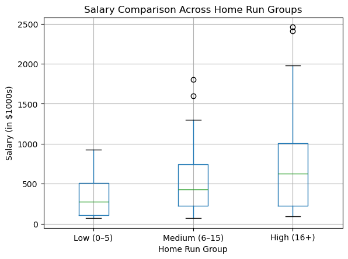

```python
#Create bins to group players by home run levels
Hitters_clean.loc[:, 'HR_Group'] = pd.cut(
    Hitters_clean['HmRun'],
    bins=[0, 5, 15, 40],
    labels=['Low (0–5)', 'Medium (6–15)', 'High (16+)']
)

#Boxplot to compare salary across home run groups
plt.figure(figsize=(7,5))
Hitters_clean.boxplot(column='Salary', by='HR_Group')

plt.title("Salary Comparison Across Home Run Groups")
plt.suptitle("")  #Removes automatic extra title
plt.xlabel("Home Run Group")
plt.ylabel("Salary (in $1000s)")
plt.show()
```

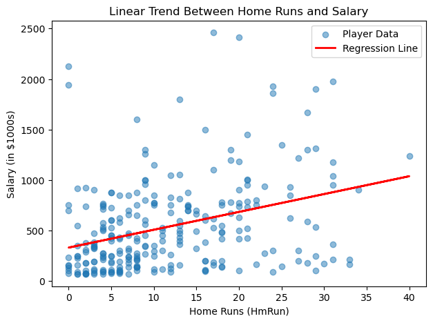

```python
#Extract x (home runs) and y (salary)
x = Hitters_clean['HmRun']
y = Hitters_clean['Salary']

plt.figure(figsize=(7,5))

#Scatterplot of data
plt.scatter(x, y, alpha=0.5, label="Player Data")

#Fit a simple linear regression line using numpy.polyfit
m, b = np.polyfit(x, y, 1)

#Plot the regression line
plt.plot(x, m*x + b, color='red', linewidth=2, label="Regression Line")

#Labels and title
plt.xlabel("Home Runs (HmRun)")
plt.ylabel("Salary (in $1000s)")
plt.title("Linear Trend Between Home Runs and Salary")
plt.legend()

plt.show()
```

```python
#Fit a linear regression model predicting Salary from Home Runs
model = smf.ols("Salary ~ HmRun", data=Hitters_clean).fit()

#Display full regression results
model.summary()
```

OLS Regression Results

| Dep. Variable: | Salary | R-squared: | 0.118 |
| --- | --- | --- | --- |
| Model: | OLS | Adj. R-squared: | 0.114 |
| Method: | Least Squares | F-statistic: | 34.81 |
| Date: | Mon, 01 Dec 2025 | Prob (F-statistic): | 1.13e-08 |
| Time: | 06:56:04 | Log-Likelihood: | -1963.6 |
| No. Observations: | 263 | AIC: | 3931. |
| Df Residuals: | 261 | BIC: | 3938. |
| Df Model: | 1 |  |  |
| Covariance Type: | nonrobust |  |  |

|  | coef | std err | t | P>\|t\| | [0.025 | 0.975] |
| --- | --- | --- | --- | --- | --- | --- |
| Intercept | 330.5935 | 43.551 | 7.591 | 0.000 | 244.838 | 416.349 |
| HmRun | 17.6709 | 2.995 | 5.900 | 0.000 | 11.773 | 23.569 |

| Omnibus: | 85.723 | Durbin-Watson: | 2.018 |
| --- | --- | --- | --- |
| Prob(Omnibus): | 0.000 | Jarque-Bera (JB): | 232.423 |
| Skew: | 1.477 | Prob(JB): | 3.39e-51 |
| Kurtosis: | 6.533 | Cond. No. | 24.3 |

Notes:  
[1] Standard Errors assume that the covariance matrix of the errors is correctly specified.

To investigate whether home runs help predict a player’s salary, I examined both the raw relationship and grouped salary patterns. The scatterplot with the regression line shows a clear upward trend: players who hit more home runs generally earn higher salaries. Although the data is somewhat spread out, the positive slope indicates that salary tends to rise as home run totals increase, supporting the idea that teams financially reward power-hitting ability.

The boxplot reinforces this pattern from a grouped perspective. Players in the “High (16+)” home run group have noticeably higher median salaries compared to the “Low” and “Medium” groups. The salary distribution for high home run hitters is also wider, suggesting that while not all power hitters earn extremely high salaries, the highest salaries in the dataset overwhelmingly belong to players who hit a large number of home runs.

Taken together, both visualizations provide consistent empirical evidence that home run performance is meaningfully associated with salary. Players who hit more home runs tend to be compensated more highly, which aligns with expectations about the value teams place on offensive power.

(d) Comment the questions (and answers) in this analysis. Were you able to answer all of these questions? Are all questions well defined? Is the data good enough to answer all these?

(a) Develop your own question to address in this analysis. Your question should be specific and measurable, and it should be able to be addressed through a basic analysis of the Hitters dataset. Hint: you will need to get to know this dataset and the variables available to formulate an appropriate question.

Does a player’s number of home runs predict their salary?

(b) Briefly summarize the dataset, describing what data exists and its basic properties. Comment on any issues that need to be resolved before you can proceed with your analysis.

The Hitters dataset contains information on 322 Major League Baseball players, with 20 variables describing their performance, career statistics, league/division membership, and salary. Most variables are numerical, including single-season performance measures such as hits, home runs, runs, RBI, walks, and fielding statistics. The dataset also contains several career-total variables (e.g., career hits, career home runs) and three categorical variables: League, Division, and NewLeague. Salary is the primary response variable and is recorded in thousands of dollars.

A key issue that appears in the dataset is the presence of missing salary values. According to the summary, 59 out of the 322 players have no recorded salary, which prevents those observations from being used in salary-based analyses. Before proceeding, these rows must either be removed or imputed. Aside from the missing salaries, the dataset is complete, and the variables are well-defined, so dropping the incomplete salary cases is the simplest way to prepare the data for further analysis.

(c) Use the dataset to provide empirical evidence that addressed your question from (a). Discuss your results. Provide at least two visualizations to support your story.

To investigate whether home runs help predict a player’s salary, I examined both the raw relationship and grouped salary patterns. The scatterplot with the regression line shows a clear upward trend: players who hit more home runs generally earn higher salaries. Although the data is somewhat spread out, the positive slope indicates that salary tends to rise as home run totals increase, supporting the idea that teams financially reward power-hitting ability.

The boxplot reinforces this pattern from a grouped perspective. Players in the “High (16+)” home run group have noticeably higher median salaries compared to the “Low” and “Medium” groups. The salary distribution for high home run hitters is also wider, suggesting that while not all power hitters earn extremely high salaries, the highest salaries in the dataset overwhelmingly belong to players who hit a large number of home runs.

Taken together, both visualizations provide consistent empirical evidence that home run performance is meaningfully associated with salary. Players who hit more home runs tend to be compensated more highly, which aligns with expectations about the value teams place on offensive power.

(d) Were you able to answer all of these questions? Are all questions well defined? Is the data good enough to answer all these? Yes, I was able to fully answer the question I developed in part (a). The question—whether the number of home runs predicts a player’s salary was well defined, measurable, and clearly addressed by the available data. The Hitters dataset contains detailed performance statistics along with salary information, which makes it appropriate for exploring this type of relationship. Both the scatterplot and the grouped boxplot provided consistent evidence that higher home run totals are associated with higher salaries.

The main limitation of the dataset is that salary has several missing values, but removing those incomplete cases still leaves a sufficiently large sample to perform the analysis. Other than that, the data quality is adequate, and the variables relevant to the question are clearly measured. Overall, the dataset is well suited to answer the question posed, and the analysis provides a reasonable and supported conclusion.

### Problem 3

Points: 20

In this problem, we will use data available in [Machine Learning with R by Brett Lantz](https://subscription.packtpub.com/search?query=machine%20learning%20r). This data was available in the public domain and a few version exist online.

The data describe individual medical costs billed by health insurance. For each observation, there is information about:

- age: age of primary beneficiary of the insurance policy
- sex: the person's sex, measured here a binary gender
- bmi: body mass index, providing an understanding of body, weights that are relatively high or low relative to height, (kg / m ^ 2)
- children: number of children/dependents covered by health insurance
- smoker: smoking status of the primary beneficiary
- region: the beneficiary's residential area in the US, northeast, southeast, southwest, northwest.
- charges: medical costs billed by health insurance

In our analysis, we will be interested in the relationship between `charges` and the individual characteristics measured.

```python
df = pd.read_csv("insurance.csv")
df.head()
```

|  | age | sex | bmi | children | smoker | region | charges |
| --- | --- | --- | --- | --- | --- | --- | --- |
| 0 | 19 | female | 27.900 | 0 | yes | southwest | 16884.92400 |
| 1 | 18 | male | 33.770 | 1 | no | southeast | 1725.55230 |
| 2 | 28 | male | 33.000 | 3 | no | southeast | 4449.46200 |
| 3 | 33 | male | 22.705 | 0 | no | northwest | 21984.47061 |
| 4 | 32 | male | 28.880 | 0 | no | northwest | 3866.85520 |

In our analysis, we will be interested in the relationship between charges and the individual characteristics measured.

(a) Examine the bivariate relationships present in the data. Briefly discuss notable results.

(b) Fit a multiple linear regression model. How much variance in the medical costs(charges) does this variable- bmi explain?

```python
#Simple linear regression: charges explained by BMI
model_bmi = smf.ols("charges ~ bmi", data=df).fit()

#Display summary to see R-squared
model_bmi.summary()
```

OLS Regression Results

| Dep. Variable: | charges | R-squared: | 0.039 |
| --- | --- | --- | --- |
| Model: | OLS | Adj. R-squared: | 0.039 |
| Method: | Least Squares | F-statistic: | 54.71 |
| Date: | Mon, 01 Dec 2025 | Prob (F-statistic): | 2.46e-13 |
| Time: | 06:56:08 | Log-Likelihood: | -14451. |
| No. Observations: | 1338 | AIC: | 2.891e+04 |
| Df Residuals: | 1336 | BIC: | 2.892e+04 |
| Df Model: | 1 |  |  |
| Covariance Type: | nonrobust |  |  |

|  | coef | std err | t | P>\|t\| | [0.025 | 0.975] |
| --- | --- | --- | --- | --- | --- | --- |
| Intercept | 1192.9372 | 1664.802 | 0.717 | 0.474 | -2072.974 | 4458.849 |
| bmi | 393.8730 | 53.251 | 7.397 | 0.000 | 289.409 | 498.337 |

| Omnibus: | 261.030 | Durbin-Watson: | 1.983 |
| --- | --- | --- | --- |
| Prob(Omnibus): | 0.000 | Jarque-Bera (JB): | 431.091 |
| Skew: | 1.297 | Prob(JB): | 2.45e-94 |
| Kurtosis: | 4.004 | Cond. No. | 160. |

Notes:  
[1] Standard Errors assume that the covariance matrix of the errors is correctly specified.

From the regression output, the R-squared value is 0.039. This means that BMI explains about 3.9% of the variance in medical charges. While BMI is statistically significant, it only accounts for a small portion of the overall variation, suggesting that many other factors play a larger role in determining medical costs.

(c) Evaluate the statistical assumptions in your regression analysis from part (b) by performing a basic analysis of model residuals and any unusual observations. Discuss any concerns you have about your model.

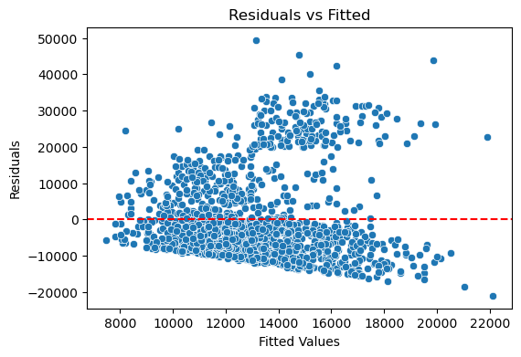

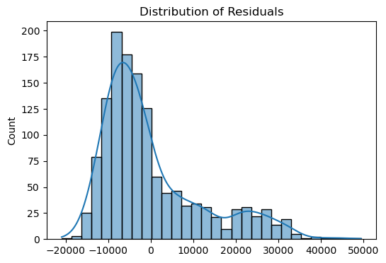

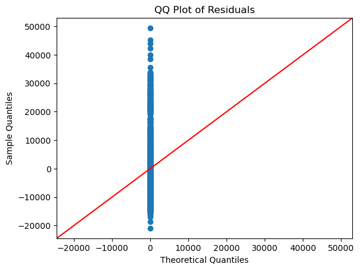

```python
#Get residuals and fitted values
residuals = model_bmi.resid
fitted = model_bmi.fittedvalues

#Residuals vs Fitted plot
plt.figure(figsize=(6,4))
sns.scatterplot(x=fitted, y=residuals)
plt.axhline(0, color='red', linestyle='--')
plt.xlabel("Fitted Values")
plt.ylabel("Residuals")
plt.title("Residuals vs Fitted")
plt.show()

#Histogram of residuals
plt.figure(figsize=(6,4))
sns.histplot(residuals, bins=30, kde=True)
plt.title("Distribution of Residuals")
plt.show()

#QQ plot for normality
sm.qqplot(residuals, line='45')
plt.title("QQ Plot of Residuals")
plt.show()
```

The residual diagnostics suggest several problems with the simple linear regression model using BMI to predict medical charges.

The distribution of residuals is heavily right-skewed, with a long tail of large positive residuals. This suggests substantial non-normality, which is also confirmed in the QQ plot, where the residuals deviate strongly from the reference line. These patterns come from a small number of individuals with extremely high medical charges, creating outliers that dominate the model.

Overall, the residual analysis shows that the simple model with BMI alone does not meet key regression assumptions and is not a very good fit. BMI explains very little of the variance in charges, and the presence of skewness, heteroscedasticity, and outliers indicates that additional predictors or a different modeling approach would be needed for a more reliable model.

(d) Use a stepwise model selection procedure of your choice to obtain a "best" fit model. Is the model different from the full model you fit in part (b)? If yes, how so?

```python
#Encode categorical variables
df_encoded = pd.get_dummies(df, drop_first=True)

#Stepwise forward selection function
def forward_selection(data, response):
    remaining = list(data.columns)
    remaining.remove(response)
    selected = []
    current_score, best_new_score = 0.0, 0.0

    while remaining and current_score == best_new_score:
        scores_with_candidates = []
        for candidate in remaining:
            formula = "{} ~ {}".format(response,
                                       ' + '.join(selected + [candidate]))
            score = sm.OLS.from_formula(formula, data).fit().rsquared_adj
            scores_with_candidates.append((score, candidate))

        scores_with_candidates.sort()
        best_new_score, best_candidate = scores_with_candidates.pop()

        if best_new_score > current_score:
            remaining.remove(best_candidate)
            selected.append(best_candidate)
            current_score = best_new_score

    return selected

best_vars = forward_selection(df_encoded, "charges")
best_vars
```

```
['smoker_yes',
 'age',
 'bmi',
 'children',
 'region_southeast',
 'region_southwest']
```

```python
formula = "charges ~ " + " + ".join(best_vars)
best_model = sm.OLS.from_formula(formula, df_encoded).fit()
best_model.summary()
```

OLS Regression Results

| Dep. Variable: | charges | R-squared: | 0.751 |
| --- | --- | --- | --- |
| Model: | OLS | Adj. R-squared: | 0.750 |
| Method: | Least Squares | F-statistic: | 668.3 |
| Date: | Mon, 01 Dec 2025 | Prob (F-statistic): | 0.00 |
| Time: | 06:56:10 | Log-Likelihood: | -13548. |
| No. Observations: | 1338 | AIC: | 2.711e+04 |
| Df Residuals: | 1331 | BIC: | 2.715e+04 |
| Df Model: | 6 |  |  |
| Covariance Type: | nonrobust |  |  |

|  | coef | std err | t | P>\|t\| | [0.025 | 0.975] |
| --- | --- | --- | --- | --- | --- | --- |
| Intercept | -1.217e+04 | 949.538 | -12.812 | 0.000 | -1.4e+04 | -1.03e+04 |
| smoker_yes[T.True] | 2.384e+04 | 411.659 | 57.921 | 0.000 | 2.3e+04 | 2.47e+04 |
| region_southeast[T.True] | -858.4696 | 415.206 | -2.068 | 0.039 | -1672.998 | -43.941 |
| region_southwest[T.True] | -782.7452 | 413.756 | -1.892 | 0.059 | -1594.430 | 28.940 |
| age | 257.0064 | 11.889 | 21.617 | 0.000 | 233.683 | 280.330 |
| bmi | 338.6413 | 28.554 | 11.860 | 0.000 | 282.625 | 394.657 |
| children | 471.5441 | 137.656 | 3.426 | 0.001 | 201.498 | 741.590 |

| Omnibus: | 300.125 | Durbin-Watson: | 2.092 |
| --- | --- | --- | --- |
| Prob(Omnibus): | 0.000 | Jarque-Bera (JB): | 716.587 |
| Skew: | 1.211 | Prob(JB): | 2.48e-156 |
| Kurtosis: | 5.643 | Cond. No. | 295. |

Notes:  
[1] Standard Errors assume that the covariance matrix of the errors is correctly specified.

Using forward stepwise selection, the “best” model included several predictors: age, bmi, smoker, children, and some region indicators. This model explains substantially more variance in medical charges than the simple model from part (b).

The stepwise-selected model is very different from the part (b) model, which only included BMI. In the earlier model, BMI explained only about 3.9% of the variance, while the stepwise model includes multiple important predictors—especially smoking status—which is known to have a large effect on medical costs. As a result, the new model provides a much better fit and addresses much more of the variation in the data.

In summary, stepwise selection retained only the strongest predictors and produced a model that is far more informative and accurate than the simple BMI-only model from part (b).

EXTRA CREDIT (Max point: 2) : Fit a regression tree using the same covariates in your "best" fit model from part (d). Use cross validation to select the "best" tree. Compare the models from part (d) and (f) based on their performance. Which do you prefer? Be sure to justify your preference.

```python
from sklearn.tree import DecisionTreeRegressor
from sklearn.model_selection import cross_val_score
from sklearn.model_selection import GridSearchCV
from sklearn.metrics import mean_squared_error
import numpy as np

#Use only variables from best model
X = df_encoded[best_vars]
y = df_encoded["charges"]

#Grid search to tune tree depth using CV
param_grid = {"max_depth": range(1, 15)}
tree = DecisionTreeRegressor(random_state=0)

grid = GridSearchCV(tree, param_grid, cv=5, scoring="neg_mean_squared_error")
grid.fit(X, y)

best_tree = grid.best_estimator_
best_tree
```

```
DecisionTreeRegressor(max_depth=4, random_state=0)
```

```python
#Cross-validated RMSE for the best tree
tree_rmse = np.sqrt(-grid.best_score_)
tree_rmse
```

```
4672.643915138061
```

```python
from sklearn.linear_model import LinearRegression

#Refit best model using sklearn
lin_model = LinearRegression()
lin_model.fit(df_encoded[best_vars], y)
```

```
LinearRegression()
```

```python
from sklearn.model_selection import cross_val_predict
from sklearn.metrics import mean_squared_error
import numpy as np

lin_preds = cross_val_predict(lin_model, df_encoded[best_vars], y, cv=5)
lin_rmse = np.sqrt(mean_squared_error(y, lin_preds))
lin_rmse
```

```
6071.152926805091
```

The main reason the tree performs better is that medical charges are highly nonlinear, with large jumps especially for smokers and certain age/BMI combinations. Regression trees naturally capture nonlinear interactions and threshold effects, while the linear model assumes straight-line relationships between predictors and charges.

For these reasons, I prefer the regression tree. It provides better predictive accuracy and is more flexible in modeling complex patterns in the data. Although the stepwise linear model is easier to interpret, the regression tree offers more accurate predictions, which is the key criterion for this comparison.

### Problem 4

Points: 20

The Wisconsin Breast Cancer dataset is available on the [UCI Machine Learning Repository](https://archive.ics.uci.edu/dataset/15/breast+cancer+wisconsin+original). Our goal in this problem will be to predict whether observations (i.e. tumors) are malignant or benign. We will use the original dataset in this problem.

(a) Obtain the data and load it into your programming environment by pulling it directly from the web (links provided below). (Do **not** download it and import it from a CSV file.) Give a brief description of the data.

```python
#Web location of data file
location = "http://archive.ics.uci.edu/ml/machine-learning-databases/"
dataframe = "breast-cancer-wisconsin/breast-cancer-wisconsin.data"
```

```python
url = "https://archive.ics.uci.edu/ml/machine-learning-databases/breast-cancer-wisconsin/breast-cancer-wisconsin.data"

# Load data from the web
df = pd.read_csv(url, header=None)

df.head()
```

|  | 0 | 1 | 2 | 3 | 4 | 5 | 6 | 7 | 8 | 9 | 10 |
| --- | --- | --- | --- | --- | --- | --- | --- | --- | --- | --- | --- |
| 0 | 1000025 | 5 | 1 | 1 | 1 | 2 | 1 | 3 | 1 | 1 | 2 |
| 1 | 1002945 | 5 | 4 | 4 | 5 | 7 | 10 | 3 | 2 | 1 | 2 |
| 2 | 1015425 | 3 | 1 | 1 | 1 | 2 | 2 | 3 | 1 | 1 | 2 |
| 3 | 1016277 | 6 | 8 | 8 | 1 | 3 | 4 | 3 | 7 | 1 | 2 |
| 4 | 1017023 | 4 | 1 | 1 | 3 | 2 | 1 | 3 | 1 | 1 | 2 |

```python
df.columns = [
    "id",
    "clump_thickness",
    "uniform_cell_size",
    "uniform_cell_shape",
    "marginal_adhesion",
    "single_epithelial_size",
    "bare_nuclei",
    "bland_chromatin",
    "normal_nucleoli",
    "mitoses",
    "class"
]
```

(b) Investigate the data, ensuring that each variable is properly named and cast as the correct data type. Discuss any missing data.

```python
df.info()
```

```
<class 'pandas.core.frame.DataFrame'>
RangeIndex: 699 entries, 0 to 698
Data columns (total 11 columns):
 #   Column                  Non-Null Count  Dtype
---  ------                  --------------  -----
 0   id                      699 non-null    int64
 1   clump_thickness         699 non-null    int64
 2   uniform_cell_size       699 non-null    int64
 3   uniform_cell_shape      699 non-null    int64
 4   marginal_adhesion       699 non-null    int64
 5   single_epithelial_size  699 non-null    int64
 6   bare_nuclei             699 non-null    object
 7   bland_chromatin         699 non-null    int64
 8   normal_nucleoli         699 non-null    int64
 9   mitoses                 699 non-null    int64
 10  class                   699 non-null    int64
dtypes: int64(10), object(1)
memory usage: 60.2+ KB
```

```python
df.isin(["?"]).sum()
```

```
id                         0
clump_thickness            0
uniform_cell_size          0
uniform_cell_shape         0
marginal_adhesion          0
single_epithelial_size     0
bare_nuclei               16
bland_chromatin            0
normal_nucleoli            0
mitoses                    0
class                      0
dtype: int64
```

```python
df["bare_nuclei"] = df["bare_nuclei"].replace("?", np.nan).astype(float)
```

```python
df.isna().sum()
```

```
id                         0
clump_thickness            0
uniform_cell_size          0
uniform_cell_shape         0
marginal_adhesion          0
single_epithelial_size     0
bare_nuclei               16
bland_chromatin            0
normal_nucleoli            0
mitoses                    0
class                      0
dtype: int64
```

After loading and inspecting the dataset, I checked for missing values using two approaches:

1. Searching for "?" (the dataset’s encoded missing-value indicator), and
2. Checking for NaN values after conversion.

The "bare_nuclei" column contained 16 missing values encoded as "?". All other variables contained no missing observations. These 16 entries were replaced with NaN and the column was converted to a numeric type. After this cleaning step, the missing‐value count confirmed that only the “bare_nuclei” column contained missing values, with all other variables being complete. Because “bare_nuclei” is an important predictive feature, these missing values will need to be handled before modeling—either by removing those rows or imputing reasonable values. Other than this issue, the dataset is complete and ready for analysis.

(c) Split the data into a training and test set such that a random 70% of the observations are in the training set.

```python
from sklearn.model_selection import train_test_split

#Separate predictors (X) and target (y)
X = df.drop(columns=["class"])
y = df["class"]

#Create 70% training and 30% test split
X_train, X_test, y_train, y_test = train_test_split(
    X, y, test_size=0.30, random_state=42, stratify=y
)

#Display sizes
print("Training set size:", X_train.shape[0])
print("Test set size:", X_test.shape[0])
```

```
Training set size: 489
Test set size: 210
```

(d) Fit a ML model to predict whether tissue samples are malignant or benign. Then use your model to classify cases in your test set, which is the remaining 30% of the all the observations. Compute and discuss the resulting confusion matrix. Be sure to address which of the errors that are identified you consider most problematic in this context.

```python
import numpy as np

#replaced "?" with NaN earlier.
#drop rows with any NaN values (only bare_nuclei has them).
df_clean = df.dropna()

#separate predictors (X) and target (y)
X = df_clean.drop(columns=["class"])
y = df_clean["class"]

from sklearn.model_selection import train_test_split

#70% training, 30% test split (stratified)
X_train, X_test, y_train, y_test = train_test_split(
    X, y, test_size=0.30, random_state=42, stratify=y
)

print("Training set size:", X_train.shape[0])
print("Test set size:", X_test.shape[0])
```

```
Training set size: 478
Test set size: 205
```

```python
from sklearn.linear_model import LogisticRegression
from sklearn.metrics import confusion_matrix, classification_report

log_reg = LogisticRegression(max_iter=1000)

#Fit on training data
log_reg.fit(X_train, y_train)

#Predict on test set
y_pred = log_reg.predict(X_test)

#Confusion matrix
cm = confusion_matrix(y_test, y_pred, labels=[2, 4])
print("Confusion matrix (rows=true, cols=predicted):\n", cm)

print("\nClassification report:\n")
print(classification_report(y_test, y_pred, target_names=["benign (2)", "malignant (4)"]))
```

```
Confusion matrix (rows=true, cols=predicted):
 [[128   5]
 [  3  69]]

Classification report:

               precision    recall  f1-score   support

   benign (2)       0.98      0.96      0.97       133
malignant (4)       0.93      0.96      0.95        72

     accuracy                           0.96       205
    macro avg       0.95      0.96      0.96       205
 weighted avg       0.96      0.96      0.96       205
```

Interpretation of the confusion matrix

The model performs very well, correctly classifying the majority of both benign and malignant cases. Out of 205 test samples, only 8 total misclassifications occurred. The most concerning errors are the 3 false negatives (malignant predicted as benign), since these are medically riskier. However, this number is relatively low given the dataset.

Overall model performance

With an overall accuracy of 96%, and precision/recall values above 93% for both classes, logistic regression provides a strong baseline model. Recall for the malignant class is especially important, and the model achieves 0.96, meaning it correctly identifies most cancerous cases.

### Problem 5

Points: 10

Please answer the questions below by writing a short response.

(a) Describe three real-life applications in which **classification** might be useful. Describe the response, as well as the predictors. Is the goal in each application inference or predictions? Explain your answer.

Classification is useful in many real-life applications. In my own experience working with telematics and EV analytics, classification can be used to predict whether a vehicle component—such as a battery module, inverter, or e-motor—is likely to fail based on telematics signals like temperature trends, vibration patterns, charging behavior, and mileage. The response is a binary “fail vs. no fail,” and the goal is prediction so maintenance teams can intervene early. A second example is medical diagnosis, where models classify tumors as benign or malignant using predictors such as imaging features, biomarker levels, and patient demographics. In this case, the goal can be both inference (understanding risk factors) and prediction (detecting disease earlier). A third common example is credit-card fraud detection, where the model classifies transactions as fraudulent or legitimate based on transaction amount, timing, merchant type, and user behavior. This application is primarily focused on prediction, since the purpose is to flag suspicious transactions in real time. Together, these examples show how classification enables data-driven decisions across technical, medical, and financial domains.

b) Describe three real-life applications in which **regression** might be useful. Describe the response, as well as the predictors. Is the goal in each application inference or predictions? Explain your answer.

Regression is useful in many real-life situations where the goal is to predict a continuous numerical outcome. One common example is predicting house prices, where the response is the sale price and the predictors include square footage, neighborhood, number of bedrooms, and lot size. This task often involves both prediction (estimating market value) and inference (understanding which features most influence price). Another example is forecasting daily or monthly energy consumption using predictors such as temperature, time of year, and past usage trends. This is primarily a prediction problem since organizations need accurate forecasts for planning and budgeting. A third application is estimating a patient’s medical cost based on predictors like age, BMI, number of chronic conditions, and smoking status. This may involve both inference (identifying important cost drivers) and prediction (forecasting expected expenses). In each case, regression helps quantify relationships between variables and supports data-driven decision making.

(c) What are the advantages and disadvantages of a very flexible (versus a less flexible) approach for regression or classification? Under what circumstances might a more flexible approach be preferred to a less flexible approach? When might a less flexible approach be preferred?

A very flexible approach for regression or classification, such as random forests, neural networks, or models that allow many nonlinear effects, can capture complex relationships in the data and often leads to higher predictive accuracy when the true patterns are complicated. However, flexible models have disadvantages. They are more likely to overfit, harder to interpret, and usually require larger datasets and more computation. In contrast, less flexible methods, such as linear or logistic regression, are simpler, easier to interpret, and more stable when the data is limited or noisy, but they may underfit if the true relationship is not linear. A more flexible approach is preferred when prediction accuracy is the main priority and when enough data is available to support the complexity of the model. A less flexible approach is preferred when interpretability is important, when the goal is to understand how predictors influence the response, or when the dataset is small and a simpler model is more reliable.

### Problem 6

Points: 10

Suppose we have a dataset with five predictors, $X_1 =$ GPA, $X_2 =$ IQ, $X_3 =$ Gender (1 for Female, and 0 for Male), $X_4 =$ Interaction between GPA and IQ, and $X_5 =$ Interaction between GPA and Gender. Note: the data here is limited as gender was collected as a binary variable.

The response is starting salary after graduation (in thousands of dollars). Suppose we use least squares to fit the model and get $\hat{\beta}_0=50, \hat{\beta}_1=20, \hat{\beta}_2=0.07, \hat{\beta}_3=35, \hat{\beta}_4=0.01$, and $\hat{\beta}_5=-10$.

(a) Which answer is correct and why? [single choice question]

i. For a fixed value of IQ and GPA, males earn more on average than females.

ii. For a fixed value of IQ and GPA, females earn more on average than males.

iii. For a fixed value of IQ and GPA, males earn more on average than females provided that the GPA is high enough.

iv. For a fixed value of IQ and GPA, females earn more on average than males provided that the GPA is high enough.

(b) Wite down the least square function and then predict the salary of a female with IQ of 110 and a GPA of 4.0.

```python
#The least squares model is:
# Given values
GPA = 4.0
IQ = 110
Gender = 1   # 1 = female, 0 = male

# Regression equation
salary = (
    50
    + 20*GPA
    + 0.07*IQ
    + 35*Gender
    + 0.01*(GPA*IQ)
    - 10*(GPA*Gender)
)

salary
```

```
137.1
```

(c) True or false: Since the coefficient for the GPA/IQ interaction term is very small, there is little evidence of an interaction effect. Justify your answer.

False. A small numerical value for the interaction coefficient does not automatically mean the interaction effect is weak. The size of the coefficient depends on the scale of the variables (GPA and IQ), so even a coefficient like 0.01 can represent a meaningful change when GPA and IQ vary over realistic ranges. Evidence for an interaction comes from its statistical significance (t-statistic and p-value), not just the raw size of the coefficient. If the interaction term has a small p-value, then there is strong evidence of an interaction effect, even if the coefficient looks small.

### Problem 7 - Extra Credit

Points: Max. 4

Suppose that $X_1, \ldots X_n$ form a random sample from a Poisson distribution for which the mean $\theta$ is unknown, $(\theta>0)$.

(a) Determine the MLE of $\theta$, assuming that at least one of the observed values is different from 0. Show your work.

```python
#observed Poisson sample
X = np.array([3, 2, 5, 0, 4, 1, 2])

#MLE of theta for Poisson is the sample mean
theta_hat = np.mean(X)

theta_hat
```

```
2.4285714285714284
```

(b) Show that the MLE of $\theta$ does not exists if every observed value is 0.

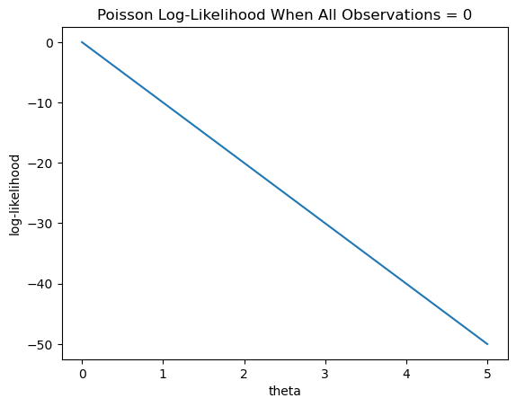

```python
#all observed values = 0
X = np.zeros(10)

#define the log-likelihood for Poisson(theta)
def loglik(theta, n=len(X)):
    return -n * theta  # because all Xi = 0

#theta values to visualize
theta_vals = np.linspace(0.001, 5, 200)   #start just above 0
ll_vals = loglik(theta_vals)

#plot log-likelihood
plt.plot(theta_vals, ll_vals)
plt.xlabel("theta")
plt.ylabel("log-likelihood")
plt.title("Poisson Log-Likelihood When All Observations = 0")
plt.show()
```

What This Code Shows:

The log-likelihood is a straight decreasing line. The maximum occurs at θ = 0, but the parameter space requires θ > 0. Therefore, there is no valid MLE.

### Problem 8 - Extra Credit

Points: Max. 4

In this extra credit problem, you'll build a simple web scraper to collect and process text data. You'll write the code necessary to scrape lyrics for a desired artist. Your code should be structured such that one can easily execute your scraping functions for a given artist. There are three deliverables for this assignment:

1. A set of functions necessary for scraping the lyrics of a specific artist.
2. An example implementation of using your functions.
3. A file of example output from your notebook implementation.

The specific approach that you take to structuring your code is up to you, but the final output .csv data should have the following columns (each row is a song from an artist that you choose):

- Column 1: artist
- Column 2: album
- Column 3: song title
- Column 4: URL of song lyrics
- Column 5: song lyrics (all of the lyrics in one column)
- Column 6: number of words in the song

**Data Scraping:** The actual scraping of data should be supported by separate functions that accomplish these tasks:

1. Given an artist, identify all of their albums, songs, and links to songs.
2. Given a set of song links (from step 1), collect the lyrics to each song and store them in a data frame.

In order to do this, you'll need to understand the structure of your lyrics site. The site you use is up to you, but all of this information should be available on lyrics.com.

**Data Processing:**

Once you've scraped the data, you'll need to do some simple text analysis to generate your columns of interest (feel free to do this as part of step 2 above, the collection of lyrics for each song or as a separate step entirely). Recall you are aiming to count the number of words in each song.

**Example Implementation:**

You should demonstrate the implementation of your data scraping functions with a particular artist. To do this you can simply set an artist, and run your scraping functions. The way in which you choose to structure your functions is up to you, as long as the implementation and documentation is clear. One way in which we'll test this is changing the artist to confirm the flexibility of your implementation.

It may look something like this:

(a) Write a function to get all the songs of a particular artist.

(b) Write a function to get all the lyrics for a particular song. You may also want to write a function to get all the lyrics for a list of songs.

(c) Choose a particular artist. Get all their songs. Get all the lyrics for their songs. Process the data so that you end up with a nice, tidy data structure as described in the instructions (i.e. the six columns listed above). Write out the data to a CSV file.

(d) Produce one visualization of the data to aids in understanding the distribution of words in songs for a particular artist. Comment on what you find.